# Simple Data Analysis and Linear and Nonlinear Classification: The Red and White Wine datasets

## MLP Modeling and Performance Estimation

Define a strategy based on nested CV searches in order to estimate as realistically as possible the performance of a MLP classifier.

In order that the execution times remain manageable, you must choose first a reasonabe MLP architecture and use **three** (3)-fold inner GridSearchCV for the parameter `alpha` (over a scaler + MLP classifier pipeline) and outer (over a best GridSearchCV estimator) using here the `cross_validate` function over the `recall` and `precision` metrics.

If needed, follow the guidelines in https://scikit-learn.org/stable/modules/cross_validation.html

**Important**: here we do not want to get a unique optimal `alpha` parameter but to estimate the `recall` and `precision` performance as precisely and cleanly as possible.

```python
#(200, 100, 10)
scaler = StandardScaler()
nn = MLPClassifier(hidden_layer_sizes=(300, 200), random_state=69, early_stopping=True, verbose=True)
```

```python
params = {'MLP__alpha': [10.**k for k in range(-6, 6)]}

pipeline = Pipeline([('scaler', scaler), ('MLP', nn)])

MLPSearch = GridSearchCV(pipeline, params, scoring=scorer.make_scorer(f1_score), n_jobs=-1)

MLP_cv_results = cross_validate(MLPSearch, X_train, y_train, scoring=['precision_macro', 'recall_macro'], cv=5,
                               return_estimator=True)
```

[output not shown]

[output cut: 8 more lines]

[output not shown]

[output not shown]

[output cut: 8 more lines]

[output not shown]

[output not shown]

[output cut: 8 more lines]

[output not shown]

[output not shown]

[output not shown]

```python
MLP_cv_results.keys()
```

```
dict_keys(['fit_time', 'score_time', 'estimator', 'test_precision_macro', 'train_precision_macro', 'test_recall_macro', 'train_recall_macro'])
```

```python
models_performance = {'MLP_'+str(i):{
    'time': MLP_cv_results['fit_time'][i],
    'estimator_alpha': MLP_cv_results['estimator'][i].best_estimator_.named_steps['MLP'].alpha,
    'recall': MLP_cv_results['test_recall_macro'][i],
    'precision': MLP_cv_results['test_precision_macro'][i]
} for i in range(5)}
```

```python
mlp_df = pd.DataFrame(models_performance)
```

```python
mlp_df
```

|  | MLP_0 | MLP_1 | MLP_2 | MLP_3 | MLP_4 |
| --- | --- | --- | --- | --- | --- |
| estimator_alpha | 0.000001 | 0.000001 | 0.000010 | 0.010000 | 0.010000 |
| precision | 0.939441 | 0.934394 | 0.952281 | 0.935108 | 0.930024 |
| recall | 0.921719 | 0.899650 | 0.937687 | 0.923451 | 0.930024 |
| time | 60.659548 | 55.427913 | 44.421571 | 48.577627 | 61.537908 |

```python
MLP_recalls = [recall for recall in MLP_cv_results['test_recall_macro']]
MLP_precision = [precision for precision in MLP_cv_results['test_precision_macro']]
print("El Recall medio en test obtenido por el Multilayer Perceptron es " +
       str(round(np.array(MLP_recalls).mean(), 2)) +
      " con un intervalo de confianza de [" +
      #utilizamos +- 2 porque la muestra de precisions y recalls es demasiado pequeña para usar el 1.96 de la Normal (tampoco es que tenga una diferencia magnífica este 0.04 de más, pero puestos a ser rigurosos, seámoslo bien).
      str(round(np.array(MLP_recalls).mean() - 2*np.array(MLP_recalls).std(), 2))+
      ", " + str(round(np.array(MLP_recalls).mean() + 2*np.array(MLP_recalls).std(), 2))+
      "]" +
      "\n y la Precision media en test ha sido de "+
      str(round(np.array(MLP_precision).mean(), 2))+
      " con un intervalo de confianza de [" +
      str(round(np.array(MLP_precision).mean() - 2*np.array(MLP_precision).std(), 2))+
      ", " + str(round(np.array(MLP_precision).mean() + 2*np.array(MLP_precision).std(), 2))+
      "]")
```

```
El Recall medio en test obtenido por el Multilayer Perceptron es 0.92 con un intervalo de confianza de [0.9, 0.95]
 y la Precision media en test ha sido de 0.94 con un intervalo de confianza de [0.92, 0.95]
```

Vemos que tenemos un recall y precision altos, además son bastante constantes (el intervalo de confianza al rededor de la media de recall y precision es suficientemente estrecho).

## SVC Modeling and Performance Estimation

Define a strategy based on nested CV searches in order to estimate as realistically as possible the performance of a SVC classifier.

You must use again **three** (3)-fold inner (over a scaler + SVC classifier pipeline) and outer (over a best GridSearchCV estimator) using also here the `cross_validate` function to estimate the `recall` and `precision` metrics.

If needed, follow the guidelines in https://scikit-learn.org/stable/modules/cross_validation.html

**Important**: here we do not want to get a unique optimal `C` and `gamma` parameter set but to estimate `recall` and `precision` performance as precisely and cleanly as possible.

```python
scaler = MinMaxScaler()

params = {'SVC__C': [10.**k for k in range(-5,5)],
         'SVC__gamma': list( np.array([2.**k for k in range(-5,5)]) / X_train.shape[1])}

svc = SVC(random_state=69)

pipeline = Pipeline([('scaler', scaler), ('SVC', svc)])

SVCSearch = GridSearchCV(pipeline, params, scoring=scorer.make_scorer(roc_auc_score), n_jobs=-1)

SVC_cv_results = cross_validate(SVCSearch, X_train, y_train, scoring=['precision_macro', 'recall_macro'], cv=5,
                               return_estimator=True)
```

```python
models_performance2 = {'SVC_'+str(i):{
    'time': SVC_cv_results['fit_time'][i],
    'estimator_C': SVC_cv_results['estimator'][i].best_estimator_.named_steps['SVC'].C,
    'estimator_gamma': SVC_cv_results['estimator'][i].best_estimator_.named_steps['SVC'].gamma,
    'recall': SVC_cv_results['test_recall_macro'][i],
    'precision': SVC_cv_results['test_precision_macro'][i]
} for i in range(5)}
```

```python
svc_df = pd.DataFrame(models_performance2)
svc_df
```

|  | SVC_0 | SVC_1 | SVC_2 | SVC_3 | SVC_4 |
| --- | --- | --- | --- | --- | --- |
| estimator_C | 10000.000000 | 10000.000000 | 1000.000000 | 10000.000000 | 10000.000000 |
| estimator_gamma | 1.142857 | 1.142857 | 2.285714 | 1.142857 | 1.142857 |
| precision | 0.937166 | 0.940625 | 0.948941 | 0.948122 | 0.937211 |
| recall | 0.924333 | 0.920412 | 0.950119 | 0.931189 | 0.932579 |
| time | 35.731467 | 33.393697 | 32.617646 | 33.940571 | 32.890353 |

```python
SVC_recalls = [recall for recall in SVC_cv_results['test_recall_macro']]
SVC_precision = [precision for precision in SVC_cv_results['test_precision_macro']]

results_df = {'model': list(models_performance.keys()) + list(models_performance2.keys()),
            'recall': MLP_recalls + SVC_recalls,
            'precision': MLP_precision + SVC_precision}
```

```python
print("El Recall medio en test obtenido por el Support Vector Classifier es " +
       str(round(np.array(SVC_recalls).mean(), 2)) +
      " con un intervalo de confianza de [" +
      str(round(np.array(SVC_recalls).mean() - 2*np.array(SVC_recalls).std(), 2))+ #we use +-2 because the sample size is not sufficient for using Normal Curve: we must use t-student.
      ", " + str(round(np.array(SVC_recalls).mean() + 2*np.array(SVC_recalls).std(), 2))+
      "]" +
      " y la Precision media en test ha sido de "+
      str(round(np.array(SVC_precision).mean(), 2))+
      " con un intervalo de confianza de [" +
      str(round(np.array(SVC_precision).mean() - 2*np.array(SVC_precision).std(), 2))+
      ", " + str(round(np.array(SVC_precision).mean() + 2*np.array(SVC_precision).std(), 2))+
      "]")
```

```
El Recall medio en test obtenido por el Support Vector Classifier es 0.93 con un intervalo de confianza de [0.91, 0.95] y la Precision media en test ha sido de 0.94 con un intervalo de confianza de [0.93, 0.95]
```

```python
SVC_cv_results.keys()
```

```
dict_keys(['fit_time', 'score_time', 'estimator', 'test_precision_macro', 'train_precision_macro', 'test_recall_macro', 'train_recall_macro'])
```

```python
for i in range(5):
    at_bound=(abs(SVC_cv_results['estimator'][i].best_estimator_.named_steps['SVC'].dual_coef_) == SVC_cv_results['estimator'][i].best_estimator_.named_steps['SVC'].C).sum()
    print("for SVM {} the number of support vectors at bound is {}".format(i, at_bound))
```

```
for SVM 0 the number of support vectors at bound is 338
for SVM 1 the number of support vectors at bound is 311
for SVM 2 the number of support vectors at bound is 326
for SVM 3 the number of support vectors at bound is 341
for SVM 4 the number of support vectors at bound is 342
```

```python
gammas = []
Cs = []
for i in range(5):
    gamma = SVC_cv_results['estimator'][i].best_estimator_.named_steps['SVC'].gamma
    gammas.append(gamma)
    C = SVC_cv_results['estimator'][i].best_estimator_.named_steps['SVC'].C
    Cs.append(C)
```

```python
for i in range(5):
    print(SVC_cv_results['estimator'][i].cv_results_)
```

[output not shown]

[output cut: 1795 more lines]

[output not shown]

## Calculating the time for different gammas and Cs

```python
times = SVC_cv_results['estimator'][0].cv_results_['mean_fit_time']
Cs = SVC_cv_results['estimator'][0].cv_results_['param_SVC__C']
gammas = SVC_cv_results['estimator'][0].cv_results_['param_SVC__gamma']
```

```python
df = pd.DataFrame({'time':times, 'C':Cs, 'gamma':gammas})
```

```python
df.shape
```

```
(100, 3)
```

```python
df2 = df.pivot(index='C', columns='gamma', values='time')
```

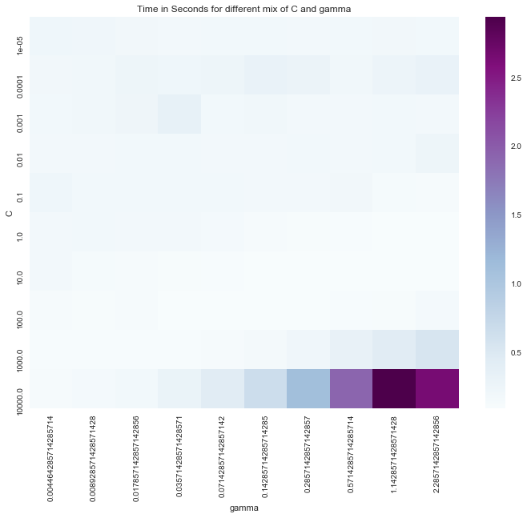

```python
plt.title('Time in Seconds for different mix of C and gamma')
sns.heatmap(df2, cmap="BuPu")
```

## Final Comparison

Summarize here the expected performance of the MLP and SVC classifiers and derive your final conclusions on both.

En este apartado veremos cómo se comportan cada uno de los modelos que hemos probado en este notebook. Para ello, primero visualizaremos cómo son las regiones de decisión de cada uno y cómo separan la muestra (esto nos enseñará de forma visual lo que hemos aprendido algorítmicamente). Utilizaré una función que he ido definiendo con ayuda de diferentes fuentes en Internet para visualizar problemas de clasificación en general; permite también clasificadores no supervisados como IsolationForest y otros. COn ella podremos ver las regiones de decisión que dibujan los clasificadores que hemos utilizado a lo largo de la práctica, y así entender cómo separan cada uno de ellos los datos. Esperamos ver formas de elipse en el svc con kernel gaussiano, y formas más bien lineales en la regresión logística.

```python
def plot_results(names, models, datasets, var_name, h = 0.02, mode="unsupervised", dec = None):

    i = 1

    figure = plt.figure(figsize=(27, 9), dpi = 50)

    for count, data in enumerate(datasets):
        '''
        pca = PCA(n_components=2)
        '''
        X, y = StandardScaler().fit_transform(data.drop(var_name, axis = 1)), data[var_name]
        '''
        X = pca.fit_transform(X)
        '''
        #X_train = pd.DataFrame(pca.fit_transform(X_train))

        #X_test = pd.DataFrame(pca.fit_transform(X_test))

        x_min, x_max = X[:, 0].min() - .5, X[:, 0].max() + .5

        y_min, y_max = X[:, 1].min() - .5, X[:, 1].max() + .5

        xx, yy = np.meshgrid(np.arange(x_min, x_max, h),
                             np.arange(y_min, y_max, h))

        cm = plt.cm.RdYlGn

        cm_bright = ListedColormap(['#FF0000', '#0cff00'])

        ax = plt.subplot(len(datasets), len(models) + 1, i)

        if count == 0:
            ax.set_title("Input data")
        # Plot the training points
        ax.scatter(X[:, 0], X[:, 1], c=y, cmap=cm_bright,
                   edgecolors='k')

        # Plot the testing points
        ax.scatter(X[:, 0], X[:, 1], c=y, cmap=cm_bright, alpha=0.6,
                   edgecolors='k')
        ax.set_xlim(xx.min(), xx.max())
        ax.set_ylim(yy.min(), yy.max())
        ax.set_xticks(())
        ax.set_yticks(())
        i += 1

        for name, clf in zip(names, models):

            ax = plt.subplot(len(datasets), len(models) + 1, i)

            if count == 0:

                if hasattr(clf, "fit"):

                    X_, y_ = pd.DataFrame(
                                          StandardScaler()\
                                           .fit_transform(datasets[count].drop(var_name, axis = 1)\
                                                         )), datasets[count][var_name]
                    clf.fit(X_, y_)

                else:

                    clf.fit_predict(X, y)

            else:

                try:
                    X_, y_ = pd.DataFrame(
                                          StandardScaler()\
                                           .fit_transform(datasets[count-1].drop(var_name, axis = 1)\
                                                         )), datasets[count-1][var_name]

                    clf.fit(X_, y_)

                except Exception as e:

                    print(e)

                    X_, y_ = pd.DataFrame(
                                          (StandardScaler()\
                                           .fit_transform(datasets[count-1].drop(var_name, axis = 1)\
                                                         )))
                    clf.fit_predict(X_, y_)

            if mode == "unsupervised":

                '''
                try:

                    preds = [1 if pred == -1 else 0 for pred in clf.predict(X)]

                except:

                    try:

                        preds = [1 if dec == -1 else 0 for dec in clf.decision_function(X)]

                    except:

                        try:

                            preds = [1 if pred == -1 else 0 for pred in clf.fit_predic(X)]

                '''
                try:
                    score = roc_auc_score(y, -clf.decision_function(X))
                except:
                    score = roc_auc_score(y, [1 if pred == -1 else 0 for pred in clf.predict(X)])

            else:
                try:
                    score = roc_auc_score(y, clf.decision_function(X))
                except:
                    score = roc_auc_score(y, clf.predict_proba(X)[:, 1])

            # Plot the decision boundary. For that, we will assign a color to each
            # point in the mesh [x_min, x_max]x[y_min, y_max].
            if hasattr(clf, "decision_function"):
                #Z = clf.decision_function(np.c_[xx.ravel(), yy.ravel()])

                try:

                    Z = clf.decision_function(np.c_[xx.ravel(), yy.ravel()])
                except:
                    Z1 = clf.decision_function(np.c_[xx.ravel()[:int(xx.ravel().shape[0]/2)], \
                                                   yy.ravel()[:int(yy.ravel().shape[0]/2)]])

                    Z2 = clf.decision_function(np.c_[xx.ravel()[int(xx.ravel().shape[0]/2):], \
                                                   yy.ravel()[int(yy.ravel().shape[0]/2):]])

                    Z = np.concatenate(Z1, Z2)
            else:

                Z = clf.predict_proba(np.c_[xx.ravel(), yy.ravel()])[:, 1]

            # Put the result into a color plot
            Z = Z.reshape(xx.shape)
            ax.contourf(xx, yy, Z, cmap=cm, alpha=.8)

            # Plot the training points
            ax.scatter(X[:, 0], X[:, 1], c=y, cmap=cm_bright,
                       edgecolors='k')
            # Plot the testing points
            #ax.scatter(X_test[:, 0], X_test[:, 1], c=y_test, cmap=cm_bright,
             #          edgecolors='k', alpha=0.6)

            ax.set_xlim(xx.min(), xx.max())
            ax.set_ylim(yy.min(), yy.max())
            ax.set_xticks(())
            ax.set_yticks(())
            if count == 0:
                ax.set_title(name)
            ax.text(xx.max() - .5, yy.min() + .8, ('%.2f' % score).lstrip('0'),
                    size=20, horizontalalignment='right')
            i += 1

    plt.tight_layout()
    plt.show()
```

```python
names = ['Logistic Regression', 'Random Forest','Multilayer Perceptron', 'Support Vector Classifier']

models = [

    LogisticRegression(C = searchLR.best_estimator_.C, random_state = 69, verbose=0, n_jobs=-1, max_iter=searchLR.best_estimator_.max_iter, solver='lbfgs'),

    RandomForestClassifier(n_estimators=500, max_depth=6, verbose=0, n_jobs=-1, random_state=69),


    MLPClassifier(hidden_layer_sizes=(300, 200), alpha = MLP_cv_results['estimator'][0].best_estimator_.named_steps['MLP'].alpha, random_state=69, verbose=0, early_stopping = True),

    SVC(C = SVC_cv_results['estimator'][0].best_estimator_.named_steps['SVC'].C,
       gamma = SVC_cv_results['estimator'][0].best_estimator_.named_steps['SVC'].gamma, probability=True, random_state=69)

]


wine3 = wine[['total sulfur dioxide', 'chlorides', 'label']]

train, test = train_test_split(wine3, test_size = 0.20, random_state=69)

datasets = [train, test]
```

```python
wine2.columns
```

```
Index(['fixed acidity', 'citric acid', 'residual sugar', 'free sulfur dioxide',
       'pH', 'alcohol', 'quality', 'label'],
      dtype='object')
```

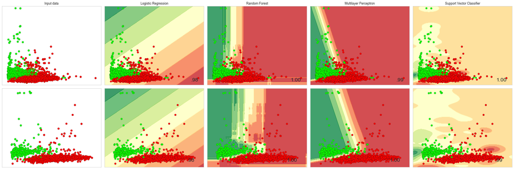

```python
plot_results(names = names, models = models, datasets=datasets, var_name='label', h = 0.02, mode="supervised", dec = None)
```

Lo más importante del gráfico de arriba al final es ver cómo toma las decisiones cada uno de los modelos que utilizamos. Fijémonos cómo el Logistic Regression crea regiones de decisión completamente lineales; por otro lado tenemos el Random Forest con unos cortes bastante más finos en los datos. Luego está MLP, que hace unos cortes algo menos lineales; en una región parece más lineal y luego se curva hacia la esquina inferior izquierda. Por último, vemos que SVC con kernel gaussiano realiza unas formas elipsodeas al rededor de los datos. No llegan a ser elipses perfectas que rodeen los datos a la perfección porque no estamos haciendo overfitting, entonces cada uno de esos márgenes que se han determinado para los patrones agrupa varios de los mismos creando unas formas bastante originales. Junto con el Random Forest parece que es el modelo que mejor separa los datos, aunque hay una diferencia muy mínima con MLP y sorprendentemente también con Logistic Regression. Es cierto que para visualizar cómo deciden los modelos hemos utilizado únicamente las dos variables que habíamos visto que eran más importantes a la hora de clasificar los vinos: total sulfur dioxide y chlorides. Como en nuestro problema más real habíamos prescindido de estas variables y demás, no tiene sentido evaluar como tal el "performance" a través de estos gráficos. Deben ser tomados como una herramienta que nos permite de forma visual entender lo que hemos visto algorítmica y matemáticamente: cómo toman decisiones los modelos. El performance de todos los modelos es lógico que sea alto porque en el primer gráfico doble de la izquierda podemos ver que tanto en el conjunto de train que hemos definido como en el conjunto de test (los hemos creado solo para la visualización con una fracción de los datos para que sea más rápido) se separan bastante bien los vinos blanco y rojo. El error de Bayes utilizando únicamente estas dos variables es pequeño y eso significa que el problema de clasificación no es tan complejo cuando usamos estas dos variables. De todas formas en la práctica se pueden encontrar numerosos casos de aplicación en los que modelos mucho más complejos como SVC o MLP no son capaces de sacar una gran ventaja a Logistic Regression.

Algo que podemos observar en los dataframes que hemos creado para los resultados de MLP y SVC en cada una de las particiones del cross validate es que en general SVC se tarda menos en entrenar (con los hiperparámetros que han salido en cada caso del GridSearch, claro) que MLP. Además, como dijimos antes los resultados para estos segundos modelos son ligeramente superiores, algo que podemos entender cuando vemos cómo dibuja cada uno sus regiones de decisión, pues la región de decisión de SVC con kernel gaussiano se ajusta mucho mejor a la forma que tienen los datos, que incluso en el caso en el que utilizamos las dos mejores variables para predecir si el vino es tinto o blanco presentan pequeñas no linealidades que son mejor capturadas por las pequeñas formas elipsoides que por la división semi-lineal que hace el MLP de los datos. Aunque los MLP son aproximadores universales de funciones, en este caso vemos que no se han sobreajustado demasiado a los datos clavando la forma que tienen estos (podría haber dibujado lunas o círculos al rededor de cada una de las clases si hubiéramos introducido una arquitectura más compleja o no le hubiéramos puesto early stopping). Si tuviéramos que quedarnos únicamente con un modelo nos quedaríamos seguramente con Support Vector Classifier con kernel gaussiano, pues es algo más estable en términos de Recall y Precision, con unos resultados tanto medios como en el intervalo de confianza que han resultado más constantes en las diferentes pruebas que hemos ido haciendo en la práctica (presentado el notebook sólo con la versión final, estas pruebas se utilizaron únicamente para perfilar aspectos de los modelos y no se han introducido aquí), teniendo unos intervalos de confianza casi siempre iguales y algo más estrechos en general que los de MLP. En estos últimos modelos que se presentan estas diferencias no parecen existir; esto tiene mucho que ver con la aleatoriedad existente en los MLP seguramente, pues pese a ponerles el mismo random state siempre, cada vez los resultados son ligeramente diferentes. Vemos que en términos de precision: $\frac{True Positive}{True Positive + False Positive}$ ambos modelos son prácticamente iguales (ver gráficas de abajo para visualizar estas diferencias), mientras que en términos de recall: $\frac{Tue Positive}{True Positive + False Negative}$ SVC ha salido algo mejor, con unas diferencias pequeñitas con respecto a MLP.

Vamos a volver a realizar el gráfico de arriba pero utilizando ahora dos variables que no separen tan claramente el vino en tinto o blanco, para ver cómo decidiría cada modelo en ese caso.

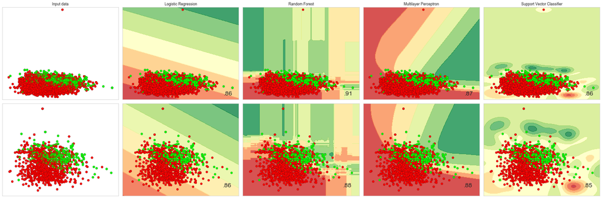

```python
wine4 = wine[['pH', 'density', 'label']]

train, test = train_test_split(wine4, test_size = 0.20, random_state=69)

datasets = [train, test]

plot_results(names=names, models=models, datasets=datasets, var_name='label', mode='supervised')
```

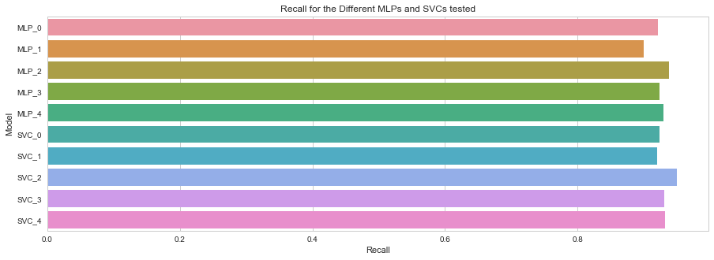

```python
plt.figure(figsize=(15,5))
plt.title('Recall for the Different MLPs and SVCs tested')
plt.xlabel('Recall')
plt.ylabel('Model')
sns.barplot(y="model", x="recall", data=results_df)
```

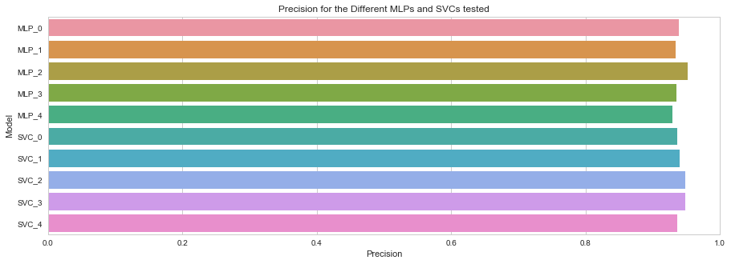

```python
plt.figure(figsize=(15,5))
plt.title('Precision for the Different MLPs and SVCs tested')
plt.xlabel('Precision')
plt.ylabel('Model')
sns.barplot(y="model", x="precision", data=results_df)
```

Vemos que visualmente no se observan unas grandes diferencias; se ve un cierto ruido de unos modelos a otros como no puede ser de otra forma utilizando CrossValidation, pero se observa una cierta homogeneidad en los mismos, lo cual es positivo en el sentido de que hemos contrastado 5 veces, haciendo 5 splits de los datos, qué tal funcionan estos dos modelos en términos de Recall y Precision, y vemos que el alto porcentaje de verdaderos positivos con respecto a los verdaderos negativos y falsos negativos (en cada caso) no viene dado por la aleatoriedad sino porque los modelos captan bien cómo clasificar los patrones que le damos de vinos para decidir si es tinto o blanco.